# 手動升級 Windows 11

## 說明

本教學適用的對象：硬體不支援使用 Windows Update 升級的電腦。

通常是記憶體少於4G，或是不支援 TPM，安裝的是網路組之前的 Win 11 版本的舊電腦。不想從新安裝新版本，因為個人資料與應用程式還要備份再做一次，又無法直接用系統內建 Update 升級。這時候最適合用本說明文件的方法。如果電腦本身可以直接透過 Windows Update 升級，那就等候系統通知更新即可，不必採用本方法。

微軟已經發布 Windows 11 26H2 版。

**👉新發現：**Windows 10 也可以用此方法升級到 Windows 11！

實測可以升級成功的版本：Windows 11 的 22H2 ~ 25H2版。可保留安裝的應用程式與個人資料不變。升級需要花點時間，時間視電腦等級而定，大約1小時左右。

雖然出意外的機率不高，但是仍建議升級前先備份資料，以免造成遺憾。

目前發現可能造成升級失敗的原因：

- 已安裝的應用程式中有不支援 26H2 的軟體。(尤其是從 Win 10 升級的電腦容易含有不支援 Win 11 的軟體)
- C 碟剩餘空間過少。(建議至少還有 30G 以上的空間)
- 硬碟或其他硬體有問題。(如記憶體毀損或硬碟壞軌造成的不穩定)
- 極少數老舊電腦無法使用 26H2。

## 升級步驟

**一. 下載安裝檔案**：從微軟下載製作 Windows 11 26H2 媒體的工具或直接下載 ISO 檔

**二. 升級 Windows** **(建議斷開網路，能節省點時間)**

#### 步驟詳解一 - 下載安裝檔案

**到微軟官網下載：** (圖片為舊版，仍可參考)

下載網址：https://www.microsoft.com/zh-tw/software-download/windows11

**第一種方法：使用工具建立安裝媒體**

微軟提供幾種不同方式供下載或升級，第一種方法：進入網頁往下找到「建立 Windows 11 安裝媒體」，點「立即下載」如下圖：

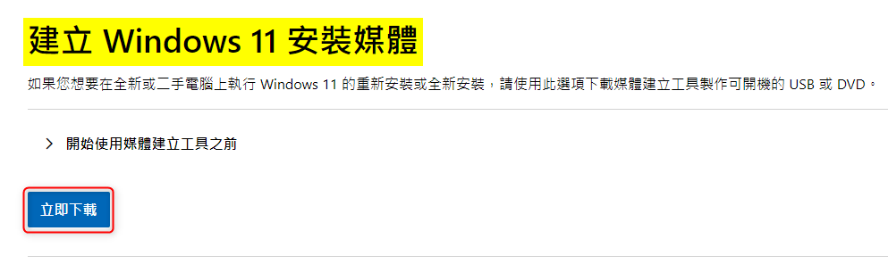

這樣會下載一個建立安裝媒體的檔案，將此檔案移到非系統碟(不是 C 碟)的地方，雙擊執行此檔案(需要管理員權限)。

我們需要的是一個 Windows 11 的安裝 ISO 檔，如下動畫圖步驟製作：

[figure not shown]

注意：Windows ISO 不要存放在 C 碟以免佔用系統空間。

**第二種方法：直接下載 ISO 檔**

同樣在此網頁往下拉，依序選擇，最後下載 ISO 檔，如下圖：

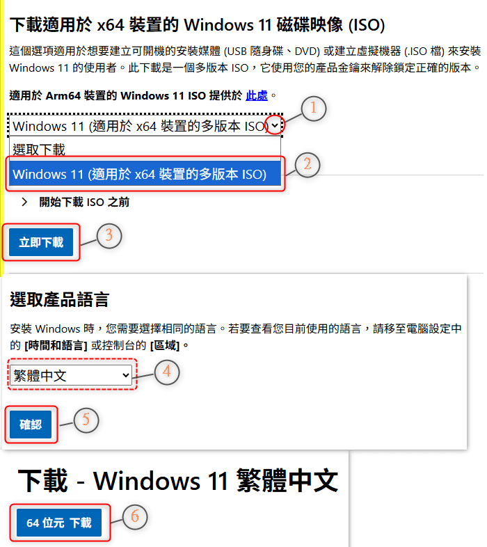

#### 步驟詳解二 - 升級 Windows

**掛載上個步驟製作或下載的 iso 檔：**

**執行以下升級步驟前請先斷開網路(拔除網路線、停用 WiFi)**，並關閉所有執行的應用程式。

**🎯透過遠端協助學員安裝時，後面有小技巧說明，可以避開搜尋更新，較節省時間。**

對 ISO 檔按右鍵選「掛接」，或是點 iso 檔之後點工具列上的「掛接」，如下圖：

[figure not shown]

以系統管理員身分開啟命令提示字元。參考下圖操作：開始 > 在搜尋處輸入 "cmd" > 點右邊的「以系統管理員身分執行」：

[figure not shown]

從開啟的命令提示字元視窗把路徑切換到掛接 ISO 檔的磁碟內的 Sources 資料夾，再輸入升級命令：

setupprep.exe /product server

例如 ISO 檔掛接成 F 碟，切換到 F 碟的 sources 資料夾，語法：cd /d F:\sources

再執行：setupprep.exe /product server如下圖：

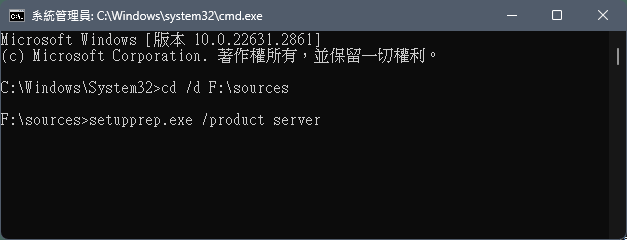

然後請按以下動畫圖步驟操作，基本上使用預設值，不用變更設定：

[figure not shown]

**👉透過遠端操作時的小技巧👈**

在上面動畫第一圖，請點「變更安裝下載更新的方式」，點下一步之後再點「現在不用」，其餘如上面動畫圖。這樣可以節省時間，如下二圖：

[figure not shown]

[figure not shown]

**備註**：因為採用安裝 server 的參數，所以出現 Windows Server 的安裝畫面，其實安裝之後只是升級到 26H2，版本還是原來的家用版或專業版。

接下來要等待升級，會花比較久的時間，先後出現如以下二圖的過程，中間會自動從新開機數次，請耐心等候。

[figure not shown]

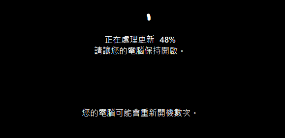

等待開機進入桌面那就大功告成。可以從“設定”>“系統”>“系統資訊”看到已經升級。

升級過後預設有 10 天的後悔期，可以回復到原先版本，不過也會占用不小的 C 碟空間。如果空間不緊張那就別理會，到期後系統會自動刪除，也可以手動刪除來騰出空間。參考官方說明請點[這裡](https://support.microsoft.com/zh-tw/windows/f8b26680-e083-c710-b757-7567d69dbb74)。

版本：2026.1030修